# Introduccción al aprendizaje estadístico Ilustración regresión lineal: airquality

Juan David Ospina Arango II Congreso Colombiano de Estadística

8 de Noviembre de 2018

# Ilustración de la regresión lineal con el conjunto de datos airquality

## Carga de los datos

Los datos están incluidos en la instalación de R. El comando *data()* pone el conjunto de datos en la memoria:

```r
data("airquality")
```

El comando *summary()* muestra algunas medidas descriptivas de las variables:

```r
summary(airquality)
```

```
##      Ozone           Solar.R           Wind             Temp
##  Min.   :  1.00   Min.   :  7.0   Min.   : 1.700   Min.   :56.00
##  1st Qu.: 18.00   1st Qu.:115.8   1st Qu.: 7.400   1st Qu.:72.00
##  Median : 31.50   Median :205.0   Median : 9.700   Median :79.00
##  Mean   : 42.13   Mean   :185.9   Mean   : 9.958   Mean   :77.88
##  3rd Qu.: 63.25   3rd Qu.:258.8   3rd Qu.:11.500   3rd Qu.:85.00
##  Max.   :168.00   Max.   :334.0   Max.   :20.700   Max.   :97.00
##  NA's   :37       NA's   :7
##      Month            Day
##  Min.   :5.000   Min.   : 1.0
##  1st Qu.:6.000   1st Qu.: 8.0
##  Median :7.000   Median :16.0
##  Mean   :6.993   Mean   :15.8
##  3rd Qu.:8.000   3rd Qu.:23.0
##  Max.   :9.000   Max.   :31.0
##
```

El conjunto de datos tiene un tamaño de:

```r
dim(airquality)
```

```
## [1] 153   6
```

Se tienen 153 observaciones, pero la variable respuesta tiene 37 valores faltantes. El comando *lm()*, que ejecuta la regresión lineal, excluirá todos los registros con valores faltantes. El analista deberá decidir si imputa los datos faltantes o si continua con un conjunto de datos de tamaño reducido.

## Análisis exploratorio

Primero graficaremos la serie de datos:

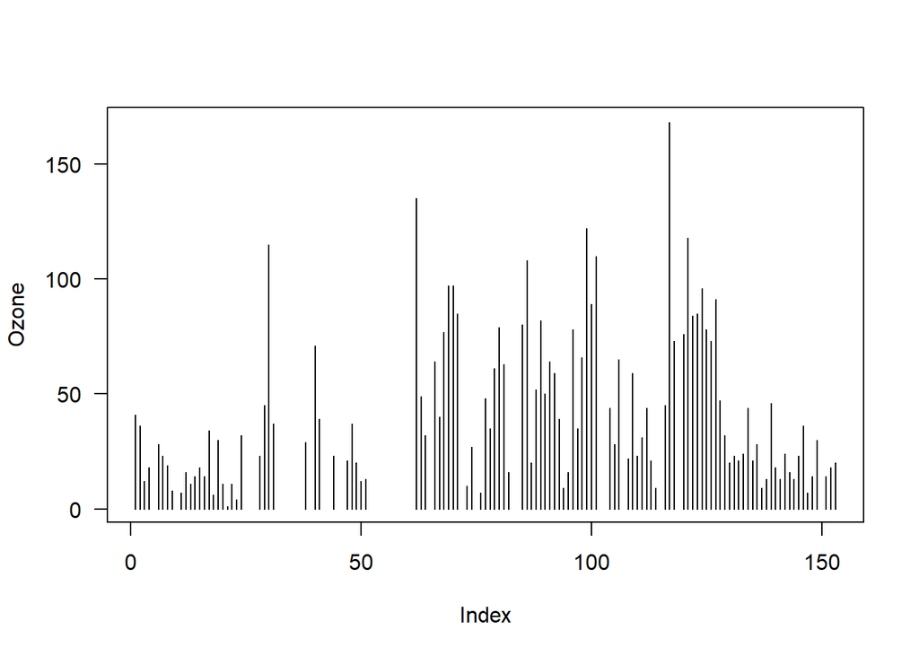

```r
with(airquality,
     plot(Ozone,type="h",las=1))
```

Para ver mejor los datos crearemos el vector de fechas:

```r
fechas<-apply(cbind(1973,airquality$Month,airquality$Day),1,paste,collapse="-")
fechas<-as.Date(fechas,"%Y-%m-%d")
```

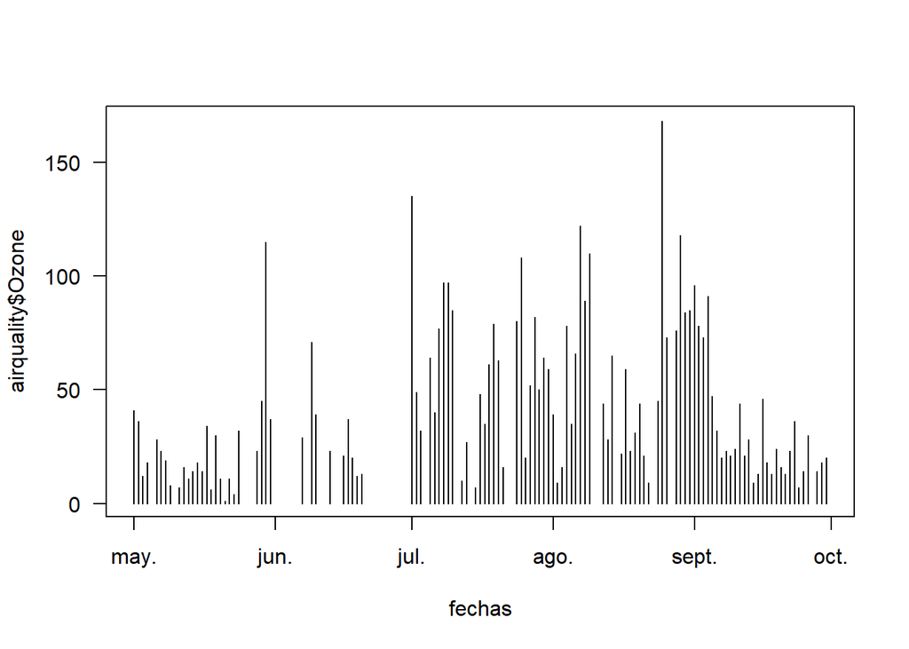

```r
plot(fechas,airquality$Ozone,type="h",las=1)
```

De la gráfica puede verse que junio es el mes con mas valores faltantes. Veamos cómo se distribuyen los valores faltantes por mes:

```r
aggregate(is.na(airquality$Ozone)~airquality$Month,FUN=sum)
```

| airquality$Month | is.na(airquality$Ozone) |
| --- | --- |
| 5 | 5 |
| 6 | 21 |
| 7 | 5 |
| 8 | 5 |
| 9 | 1 |

Extraigamos ahora de la fecha los nombres del mes y del día de la semana;

```r
fechas_mes<-months(fechas)
fechas_dia<-weekdays(fechas)
```

Desafortunadamente, los vectores anteriores no contienen información sobre el orden natural de sus valores. Esta información debe agregarse manualmente así:

```r
fechas_mes<-factor(fechas_mes,
                      levels=c("mayo","junio","julio",
                               "agosto","septiembre"))
fechas_dia<-factor(fechas_dia,levels=c("lunes","martes","miércoles",
                                      "jueves","viernes","sábado",
                                      "domingo"))
```

Ahora puede verse mejor la distribución de los datos faltantes. Para los meses se tiene:

```r
aggregate(is.na(airquality$Ozone)~fechas_mes,FUN=sum)
```

| fechas_mes | is.na(airquality$Ozone) |
| --- | --- |
| mayo | 5 |
| junio | 21 |
| julio | 5 |
| agosto | 5 |
| septiembre | 1 |

Y para los días de la semana se tiene:

```r
aggregate(is.na(airquality$Ozone)~fechas_dia,FUN=sum)
```

| fechas_dia | is.na(airquality$Ozone) |
| --- | --- |
| lunes | 5 |
| martes | 3 |
| miércoles | 5 |
| jueves | 6 |
| viernes | 7 |
| sábado | 7 |
| domingo | 4 |

Otra forma de explorar la relación de la contaminación con la fecha es con el diagrama de caja y bigotes:

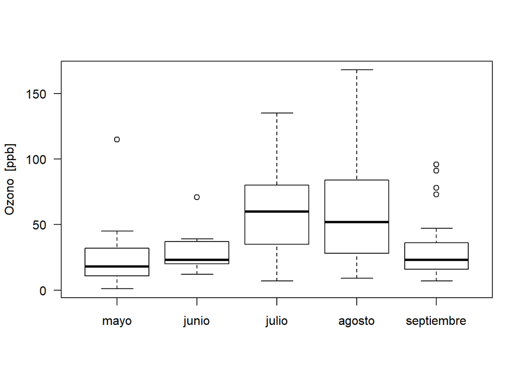

```r
boxplot(airquality$Ozone~fechas_mes, ylab="Ozono  [ppb]",las=1)
```

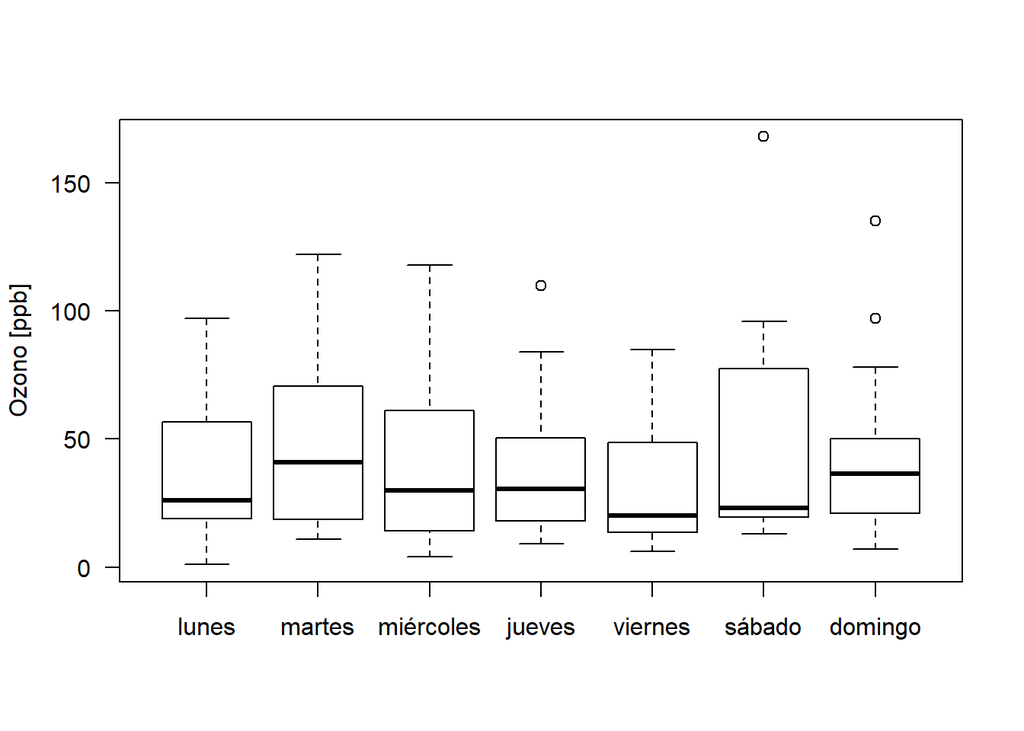

```r
boxplot(airquality$Ozone~fechas_dia, ylab="Ozono [ppb]",las=1)
```

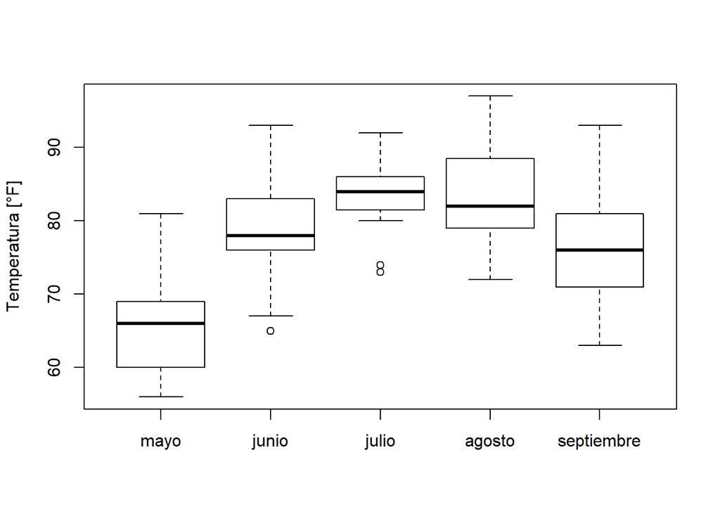

```r
boxplot(airquality$Temp~fechas_mes, ylab="Temperatura [°F]")
```

Veamos lo que ocurre para la radiación solar:

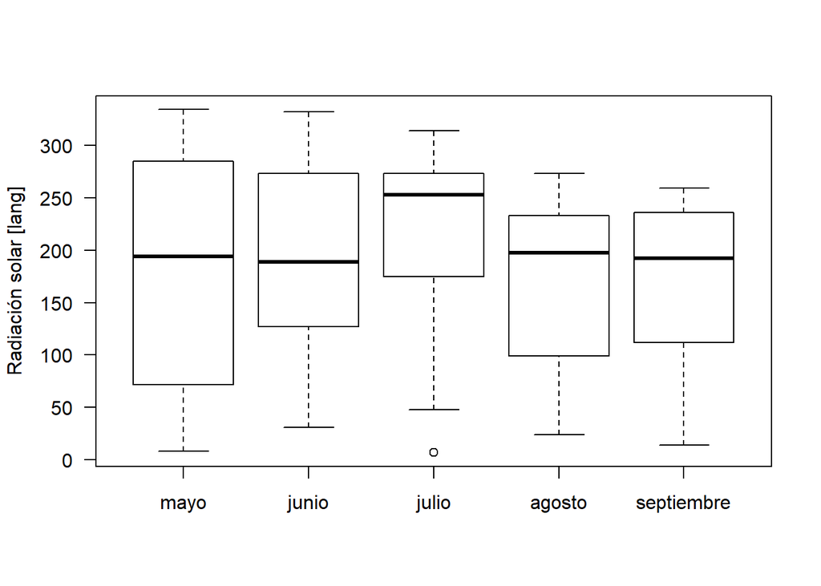

```r
boxplot(airquality$Solar.R~fechas_mes, ylab="Radiación solar [lang]", las=1)
```

Veamos qué pasa cuando pasamos a la escala logarítmica:

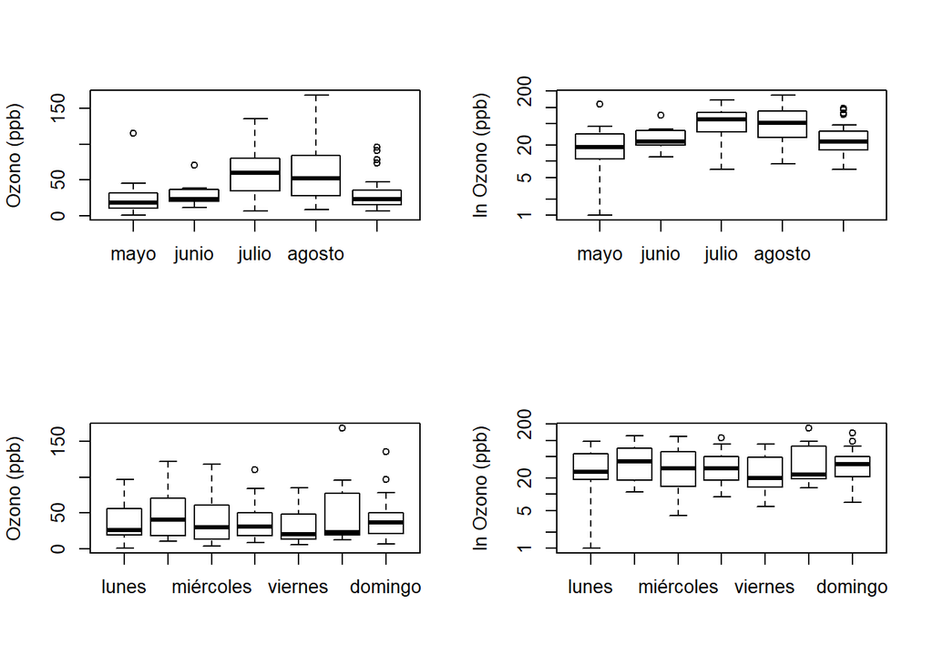

```r
par(mfrow=c(2,2))
boxplot(airquality$Ozone~fechas_mes,ylab="Ozono (ppb)")
boxplot(airquality$Ozone~fechas_mes,log="y",ylab="ln Ozono (ppb)")
boxplot(airquality$Ozone~fechas_dia,ylab="Ozono (ppb)")
boxplot(airquality$Ozone~fechas_dia,log="y",ylab="ln Ozono (ppb)")
```

Hasta este punto la transformación logarítmica no resulta ser muy útil. Más adelante se verá su utilidad.

### Gráfico de dispersión por pares

Ahora se obtendrá el gráfico de dispersión por pares. Antes de obtenerla definiremos la función *panel.cor()*, que escribirá la correlación entre los distintos pares de variables:

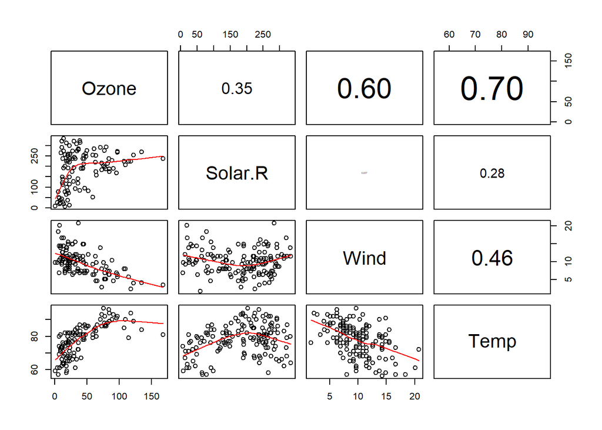

```r
panel.cor <- function(x, y, digits = 2, prefix = "", cex.cor, ...)
{
    usr <- par("usr"); on.exit(par(usr))
    par(usr = c(0, 1, 0, 1))
    r <- abs(cor(x, y,use="na.or.complete"))
    txt <- format(c(r, 0.123456789), digits = digits)[1]
    txt <- paste0(prefix, txt)
    if(missing(cex.cor)) cex.cor <- 0.8/strwidth(txt)
    text(0.5, 0.5, txt, cex = cex.cor * r)
}
pairs(airquality[,1:4], lower.panel = panel.smooth, upper.panel = panel.cor)
```

Obtengamos el mismo gráfico pero poniendo la variable Ozone en escala logarítmica (note los cambios en la función *panel.cor()* para visualizar correctamente el cambio de escala):

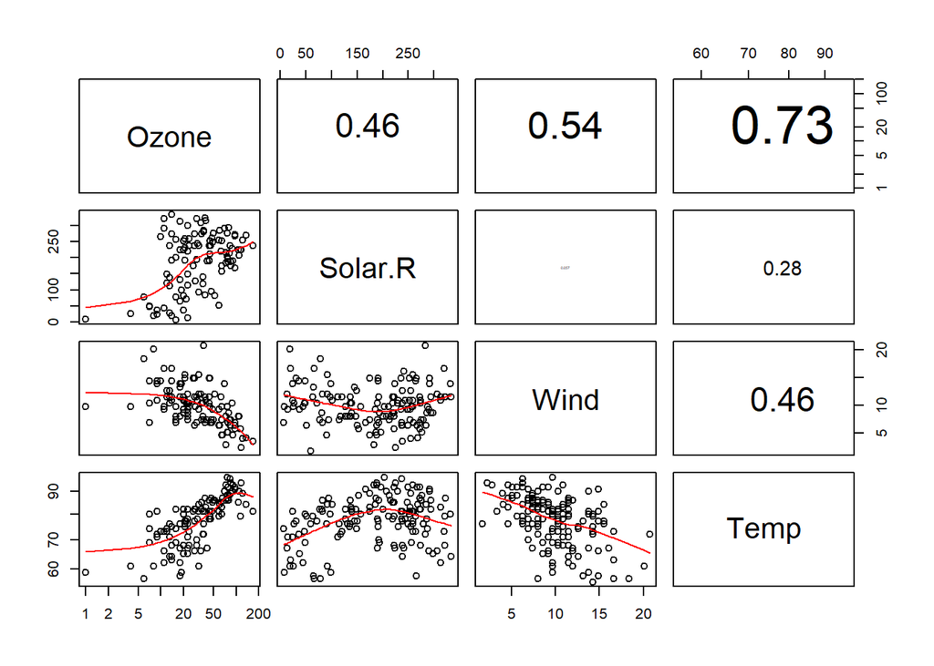

```r
panel.cor <- function(x, y, digits = 2, prefix = "", cex.cor, ...)
{
    usr <- par("usr"); on.exit(par(usr))
    if(par("xlog")){x<-log(x)}
    if(par("ylog")){y<-log(y)}
    par(usr = c(0, 1, 0, 1))
    r <- abs(cor(x, y,use="na.or.complete"))
    txt <- format(c(r, 0.123456789), digits = digits)[1]
    txt <- paste0(prefix, txt)
    if(missing(cex.cor)) cex.cor <- 0.8/strwidth(txt)
    pos_x<-ifelse(par("xlog"),4,0.5)
    pos_y<-ifelse(par("ylog"),4,0.5)
    text(pos_x,pos_y, txt, cex = cex.cor * r)
}
pairs(airquality[,1:4], lower.panel = panel.smooth, upper.panel = panel.cor,log = c(1,4))
```

# Estimación de un modelo de regresión lineal

## Estimación con *lm()*

Estimaremos un modelo logarítmico utilizando la función *lm()*:

```r
modelo<-lm(I(log(Ozone))~Wind+Solar.R+I(Solar.R^2)+Temp,data=airquality)
```

Veamos el desempeño del modelo:

```r
summary(modelo)
```

```
##
## Call:
## lm(formula = I(log(Ozone)) ~ Wind + Solar.R + I(Solar.R^2) +
##     Temp, data = airquality)
##
## Residuals:
##     Min      1Q  Median      3Q     Max
## -1.9005 -0.2702  0.0025  0.3128  1.1195
##
## Coefficients:
##                Estimate Std. Error t value Pr(>|t|)
## (Intercept)  -2.369e-01  5.458e-01  -0.434 0.665200
## Wind         -5.876e-02  1.555e-02  -3.779 0.000261 ***
## Solar.R       7.259e-03  2.399e-03   3.026 0.003113 **
## I(Solar.R^2) -1.413e-05  6.957e-06  -2.031 0.044735 *
## Temp          4.492e-02  6.355e-03   7.068 1.74e-10 ***
## ---
## Signif. codes:  0 '***' 0.001 '**' 0.01 '*' 0.05 '.' 0.1 ' ' 1
##
## Residual standard error: 0.5013 on 106 degrees of freedom
##   (42 observations deleted due to missingness)
## Multiple R-squared:  0.677,  Adjusted R-squared:  0.6648
## F-statistic: 55.54 on 4 and 106 DF,  p-value: < 2.2e-16
```

Ahora observemos los diferentes gráficos diangósticos del modelo:

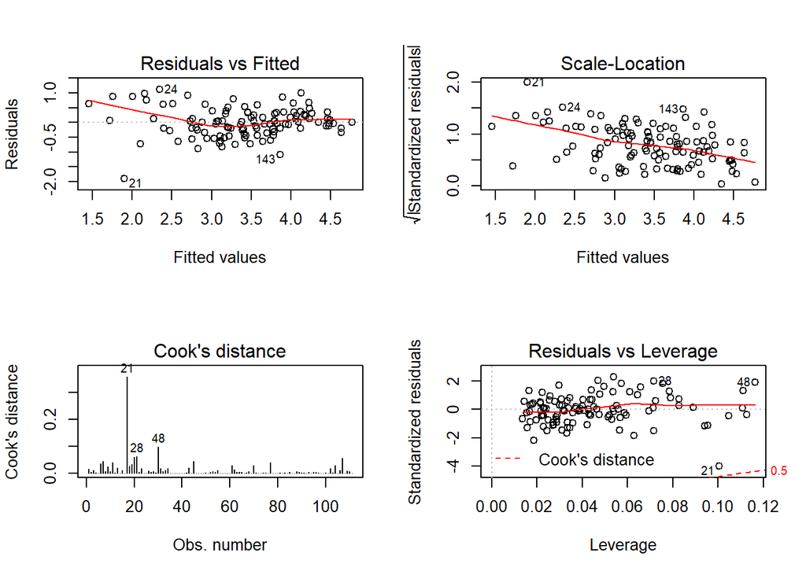

```r
par(mfrow=c(2,2))
plot(modelo,which=1)
plot(modelo,which=3)
plot(modelo,which=4)
plot(modelo,which=5)
```

## Estimación “manual”

En esta sección se presenta la estimación del modelo anterior utilizando la [factorización matricial QR](https://en.wikipedia.org/wiki/QR_decomposition) ([enlace útil](http://genomicsclass.github.io/book/pages/qr_and_regression.html)).

En lo que sigue asumimos que el modelo de regresión lineal se escribe de forma matricial como $Y=X\beta+\varepsilon$, donde $Y$ es un vector de $n\times 1$, $X$ es una matriz de datos de dimensión $n \times p$, $\beta$ es un vector de coeficientes de dimensión $p\times 1$ y $\varepsilon$ es un vector de errores de dimensión $n\times 1$ de media $0 \times 1_{n}$, dispersión $\Sigma=\sigma^2 I_{n\times n}$.

El estimador del vectro de coeficientes se puede obtener como $\hat \beta = (X^TX)^{-1}X^TY$, pero también como el vector que satisface $X^TX \beta=X^TY$.

Construyamos el vector $Y$ y la matriz de datos $X$:

```r
Y<-log(airquality$Ozone)
X0<-rep(1,length(Y))
X1<-airquality$Wind
X2<-airquality$Solar.R
X3<-airquality$Solar.R^2
X4<-airquality$Temp
X<-as.matrix(cbind(X0,X1,X2,X3,X4))
Y<-as.matrix(Y,nrow=length(Y),ncol=1)
```

Para estimar el modelo es necesario eliminar los valores faltantes. Podemos utilizar el siguiente código para encontrarlos:

```r
filas_con_NA<-which(is.na(apply(cbind(X,Y),1,sum)))
```

Ahora se retiran los valores faltantes:

```r
Y<-Y[-filas_con_NA,1]
X<-X[-filas_con_NA,]
```

Para estimar $\beta$ primero se calculará $(X^TX)^{-1}X^T$:

```r
X_g<-solve(t(X)%*%X)%*%t(X)
```

Ahora se obtienen los coeficientes estimados:

```r
b<-X_g%*%Y
```

La matriz de proyección $H$ se define como $H=X(X^TX)^{-1}X^T$ y se calcula así:

```r
H<-X%*%solve(t(X)%*%X)%*%t(X)
```

Utilizando la matriz $H$ se puede calcular el vector de residuales sin utilizar los coeficientes, así:

```r
I_nn<-diag(1,nrow=length(Y))
r<-(I_nn-H)%*%Y
```

Lo anterior permite tener un estimador de $\sigma^2$, así:

```r
s2<-t(r)%*%r/(length(Y)-4-1)
s<-sqrt(s2)
print(s)
```

```
##           [,1]
## [1,] 0.5013012
```

### Con la descomposición QR

Si se aplica la factorización QR sobre $X$, entonces ésta puede escribirse como $X=QR_1$, con $Q$ [matriz ortogonal](https://en.wikipedia.org/wiki/Orthogonal_matrix) y $R_1=[R^T \ 0_{(n-p)\times p}^T]^T$, con $R$ matriz triangular superior. Esta descomposicón se obtiene con la función *qr()*:

```r
QR_des<-qr(X)
```

Ahora se obtienen las matrices $Q$ y $R$:

```r
Q<-qr.Q(QR_des)
R<-qr.R(QR_des)
```

La matriz $Q$ se puede visualizar como imagen así:

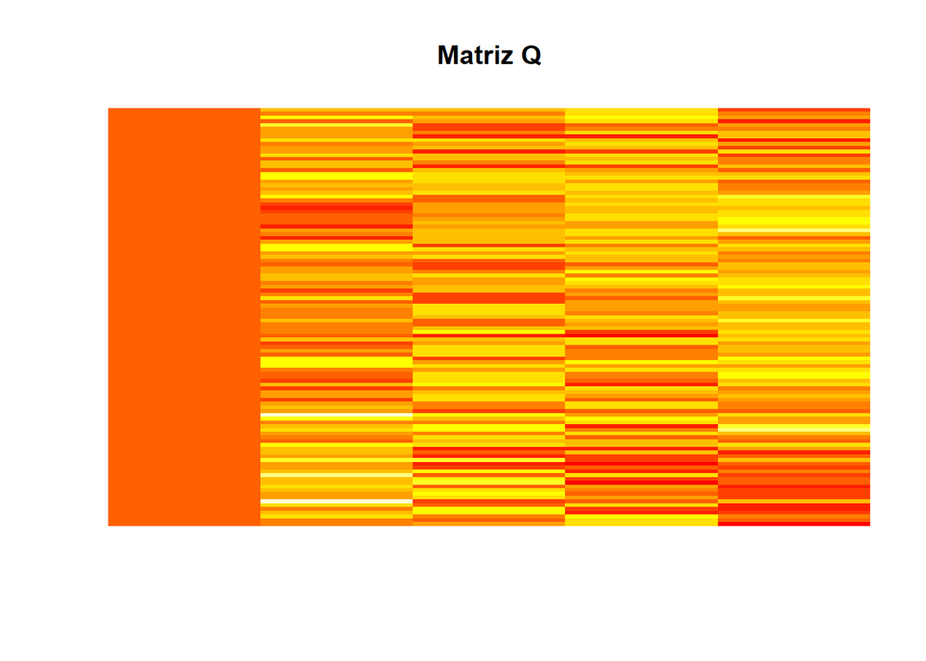

```r
image(t(Q),main="Matriz Q",axes=FALSE)
```

La matriz $R$ de dimensión $p\times p$ se visualiza simplemente con *print()*:

```r
print(R)
```

```
##             X0         X1         X2         X3         X4
## [1,] -10.53565 -104.72060 -1947.0078 -446559.95 -819.59793
## [2,]   0.00000   37.31361  -121.5891  -18455.87  -49.69469
## [3,]   0.00000    0.00000   948.2498  311345.49   23.26297
## [4,]   0.00000    0.00000     0.0000  -76324.55   27.52764
## [5,]   0.00000    0.00000     0.0000       0.00   78.87798
```

Para estimar $\beta$ recordemos que este satisface $X^TX \beta=X^TY$. Pero $X^TX=R^TR$, así que primero puede resolverse por sustitución el sistema $R^Tz=X^TY$ para $z$ y luego se resuelve por sustitución el sistema $R\beta=z$ para $\beta$.

Obtengamos $X^TY$:

```r
XY<-t(X)%*%Y
print(XY)
```

```
##            [,1]
## X0 3.791679e+02
## X1 3.580490e+03
## X2 7.403078e+04
## X3 1.708641e+07
## X4 3.017260e+04
```

Ahora obtengamos $z$ por sustitución utilizando la función *backsolve()* con el comando upper.tri=FALSE (ya que $R^T$ es una matriz triangular inferior):

```r
z<-backsolve(t(R),XY,upper.tri = FALSE)
print(z)
```

```
##            [,1]
## [1,] -35.989027
## [2,]  -5.046480
## [3,]   3.528883
## [4,]   2.314956
## [5,]   3.543003
```

Finalmente obtengamos $\beta$ por sustitución utilizando nuevamente la función *backsolve()*:

```r
beta<-backsolve(R,z)
print(beta)
```

```
##               [,1]
## [1,] -2.368535e-01
## [2,] -5.875839e-02
## [3,]  7.259004e-03
## [4,] -1.413023e-05
## [5,]  4.491752e-02
```

Comparemos los coeficientes obtenidos de las tres maneras:

```r
cbind(coefficients((modelo)),b,beta)
```

```
##                       [,1]          [,2]          [,3]
## (Intercept)  -2.368535e-01 -2.368535e-01 -2.368535e-01
## Wind         -5.875839e-02 -5.875839e-02 -5.875839e-02
## Solar.R       7.259004e-03  7.259004e-03  7.259004e-03
## I(Solar.R^2) -1.413023e-05 -1.413023e-05 -1.413023e-05
## Temp          4.491752e-02  4.491752e-02  4.491752e-02
```

```r
beta_2<-backsolve(R,(t(Q)%*%Y)[1:5])
print(beta_2)
```

```
## [1] -2.368535e-01 -5.875839e-02  7.259004e-03 -1.413023e-05  4.491752e-02
```

Para los errores estándar se tiene que $\hat {Cov}(\hat \beta)=\hat{\sigma}^2(X^TX)^{-1}$. Pero $(X^TX)^{-1}=(R^TQ^TQR)^{-1}=(R^TR)^{-1}=R^{-1}(R^T)^{-1}$.

Ahora, como $R$ es una matriz triangular, su inversa se puede obtener por sustitución del sistema $Rx=u$, para $u$, donde $u$ toma los valores $e_1=(1 \ 0 \ \ldots \ 0)^T$, $e_2=(0 \ 1 \ \ldots \ 0)^T$, $e_p=(0 \ 0 \ \ldots \ 1)^T$. Para cada vector $e_i$ se obtiene el respectivo valor de $x$ que es la $i$-ésima columna de $R^{-1}$ ([ver enlace](https://math.stackexchange.com/questions/1143214/method-to-find-the-inverse-of-any-lower-triangular-matrix)). Así se tiene:

```r
e1<-c(1,0,0,0,0)
e2<-c(0,1,0,0,0)
e3<-c(0,0,1,0,0)
e4<-c(0,0,0,1,0)
e5<-c(0,0,0,0,1)
r_1<-backsolve(R,e1)
r_2<-backsolve(R,e2)
r_3<-backsolve(R,e3)
r_4<-backsolve(R,e4)
r_5<-backsolve(R,e5)
```

Luego $R^{-1}$ se obtiene concatenando los vectores r_i así:

```r
r_inv<-as.matrix(cbind(r_1,r_2,r_3,r_4,r_5))
```

Veamos que r_inv es en efecto $R^{-1}$:

```r
R%*%r_inv
```

```
##      r_1 r_2 r_3          r_4           r_5
## [1,]   1   0   0 0.000000e+00 -1.776357e-15
## [2,]   0   1   0 2.775558e-17  0.000000e+00
## [3,]   0   0   1 0.000000e+00 -5.551115e-17
## [4,]   0   0   0 1.000000e+00 -5.551115e-17
## [5,]   0   0   0 0.000000e+00  1.000000e+00
```

Podemos observar que algunos elementos por fuera de la diagonal no son exactamente cero. Esto se llama *error de redondeo* y puede tener implicaciones en los resultados finales de la estimación. El no invertir la matrix $R$ sin embargo, representa una eficiencia importante en términos de tiempo.

Como $(R^T)^{-1}=(R^{-1})^{T}$ ya podemos entonces calcular $(X^TX)^{-1}$:

```r
XTX_inv<-r_inv%*%t(r_inv)
print(XTX_inv)
```

```
##               [,1]          [,2]          [,3]          [,4]          [,5]
## [1,]  1.185395e+00 -2.322958e-02  1.753513e-04 -3.445021e-07 -1.238284e-02
## [2,] -2.322958e-02  9.621656e-04  1.205307e-05 -3.821426e-08  1.678601e-04
## [3,]  1.753513e-04  1.205307e-05  2.290258e-05 -6.464940e-08 -2.297629e-05
## [4,] -3.445021e-07 -3.821426e-08 -6.464940e-08  1.925683e-10  5.796865e-08
## [5,] -1.238284e-02  1.678601e-04 -2.297629e-05  5.796865e-08  1.607269e-04
```

Finalmente la matriz de covariazas estimada de los coeficientes es:

```r
cov_b<-as.numeric(s2)*XTX_inv
print(cov_b)
```

```
##               [,1]          [,2]          [,3]          [,4]          [,5]
## [1,]  2.978931e-01 -5.837660e-03  4.406629e-05 -8.657436e-08 -3.111842e-03
## [2,] -5.837660e-03  2.417949e-04  3.028970e-06 -9.603354e-09  4.218373e-05
## [3,]  4.406629e-05  3.028970e-06  5.755484e-06 -1.624658e-08 -5.774007e-06
## [4,] -8.657436e-08 -9.603354e-09 -1.624658e-08  4.839295e-11  1.456769e-08
## [5,] -3.111842e-03  4.218373e-05 -5.774007e-06  1.456769e-08  4.039112e-05
```

Comparemos el resultado obtenido con la función $vcov$ que extrae la matriz de dispersión estimada de los coeficientes:

```r
vcov(modelo)
```

```
##                (Intercept)          Wind       Solar.R  I(Solar.R^2)
## (Intercept)   2.978931e-01 -5.837660e-03  4.406629e-05 -8.657436e-08
## Wind         -5.837660e-03  2.417949e-04  3.028970e-06 -9.603354e-09
## Solar.R       4.406629e-05  3.028970e-06  5.755484e-06 -1.624658e-08
## I(Solar.R^2) -8.657436e-08 -9.603354e-09 -1.624658e-08  4.839295e-11
## Temp         -3.111842e-03  4.218373e-05 -5.774007e-06  1.456769e-08
##                       Temp
## (Intercept)  -3.111842e-03
## Wind          4.218373e-05
## Solar.R      -5.774007e-06
## I(Solar.R^2)  1.456769e-08
## Temp          4.039112e-05
```

Para completar el ejercicio simplemente calcularemos los estadísticos t y los respectivos valores p:

```r
gl<-dim(X)[1]-4-1 #grados de libertad
T_estadisticos<-b/sqrt(diag(cov_b))
valores_p<-2*pt(-abs(T_estadisticos),gl)
print(cbind(T_estadisticos,valores_p))
```

```
##          [,1]         [,2]
## X0 -0.4339599 6.651995e-01
## X1 -3.7787338 2.607451e-04
## X2  3.0257715 3.112589e-03
## X3 -2.0312249 4.473461e-02
## X4  7.0676134 1.738369e-10
```